# Raji model cell counts

L. Meuris

2026-04-20

# Description of experiments

Purpose of the experiment is to look at the effect of MGAT5 engineering in CART-cells in a mouse tumor model. The model uses Raji cells, which create blood tumors of the Burkitt’s lymphoma type. These cells are CD19, CD20 and CD70 positive.

The experiments have appr. the following timelines:

- day -1 or -2: weight baseline measurement
- day 0: injection of Raji cells IV
- day 4, 5 or 6: start of weight and IVIS measurements
- day: 7 CART cell injection
- around day 130: rechallenge if applicable

Careful; depending on the data source file, the days can be relative to injection of Raji cells, but also relative to the start of the CART cell engineering, which starts typically 6 days earlier. That means that the day of Raji injection would become day 6 and CART cell injection day 13.

The mice are followed up via body weight measurements and IVIS data and some blood is taken at several timepoints to count the number of CAR cells (GFP+) in the blood.

There are several experiments:

Experiment 51:

- PBS: no cells given
- NTC: 4 million cells donor T-cells, no CAR T cells
- CD70 CART WT 4 million cells
- CD70 CART MGAT5 4 million cells
- CD70 CART WT 2 million cells
- CD70 CART MGAT5 2 million cells
- CD20 CART WT 1 million cells
- CD20 CART MGAT5 1 million cells
- CD20 CART WT 0.5 million cells
- CD20 CART MGAT5 0.5 million cells

Experiment 62 and 68:

- NTC: 4 million cells donor T-cells, no CAR T cells
- CD70 CART WT 4 million cells
- CD70 CART MGAT5 4 million cells
- CD20 CART WT 0.5 million cells
- CD20 CART MGAT5 0.5 million cells
- CD19 CART WT 2 million cells
- CD19 CART MGAT5 2 million cells

- NTC: 4 million cells donor T-cells, no CAR T cells
- CD70 CART WT 4 million cells
- CD70 CART MGAT5 4 million cells
- CD20 CART WT 0.5 million cells
- CD20 CART MGAT5 0.5 million cells

Experiment 91, 97 and 103:

- NTC
- CD19 CART WT
- CD19 CART MGAT5

Summarizing we can say that:

1. there are 3 CART targets: CD19, CD20, CD70
2. different amounts of CART cells have been injected; 0.5, 2 or 4 million
3. CART cells were either engineered or not to have MGAT5 knocked out

There was a rechallenge part to experiments 51 and 74 but not to 62, 68, 91 and 97. Exp 103 is still running. A rechallenge means that tumor cells were administered again after a set period. We also note the end-day of the experiments.

Note: for Exp 91, the IVIS machine was unavailable, so it was terminated prematurely. Note 2: in the analyses below, the CD20 data is not used. The metadata thus only contains info on the mice that are used.

```r
# These are days since tumor inoculation
day_rechallenge_E51 <- 133
day_rechallenge_E62 <- NA
day_rechallenge_E68 <- NA
day_rechallenge_E74 <- 139
day_rechallenge_E91 <- NA
day_rechallenge_E97 <- NA #26/3/26: in fact, there was a rechallenge, but ignored it since too little mice for plots and stats
day_rechallenge_E103 <- NA #26/3/26: exp still running, rechallenge may or may not happen

day_end_E51 <- 216
day_end_E62 <- 83
day_end_E68 <- 88
day_end_E74 <- 202
day_end_E91 <- 25
day_end_E97 <- 137 #26/3/26: did not end on day 137, but decided to use this as end date, since too few mice for rechallenge.
day_end_E103 <- 63 #26/3/26: exp still running, end date not final
```

# Data

The data are from a flow cytometry experiment which analyzed the number of CART cells in the blood of mice in the Raji tumor model treated with different versions of CAR T-cells or controls. The following variables are in the dataset:

*For all day variables: Still need to clarify whether this is days since T cell isolation, days since tumor injection or still another reference point (e.g. days since CART injection)?*

```r
data <- read_xlsx(here('data/data_counts_cleaned.xlsx'))
```

Cleaning: remove sentinel mice Cleaning: remove ‘No Raji’ controls Cleaning: 3 rows that have missing data for CellCount (due to low counting beads)

```r
data <- data %>%
  filter(Treatment != 'sentinel') %>%
  filter(!str_detect(Treatment, 'No Raji')) %>%
  filter(!is.na(CellCount_pul))
```

Cleaning: remove treatments in exp 51 that were for dose finding and not repeated in other experiments. This is: remove treatments with 2 million cells for CD70. Then strip the dose information from the Treatment variable.

```r
data <- data %>%
  filter(!Treatment %in% c('CD70 WT CAR - 2', 'CD70 M5KO CAR - 2')) %>%
  mutate(Treatment = str_remove(Treatment, ' - \\d(\\.\\d)?'))
```

Remove ‘Raji +’ from some treatment names.

```r
data <- data %>%
  mutate(Treatment = str_remove(Treatment, 'Raji \\+ '))
```

What is left now?

```r
data$Treatment %>% unique
```

```
## [1] "NTC"                     "CD19 CAR - mock"
## [3] "CD19 CAR - MGAT5 KO"     "CD70 WT CAR"
## [5] "CD70 M5KO CAR"           "CD70 nanoCAR - neg ctrl"
## [7] "CD70 nanoCAR - MGAT5 KO"
```

Rename treatments that are identical but have a different name.

```r
data <- data %>%
  mutate(Treatment = case_when(
    Treatment == 'NTC' ~ 'NTC',
    Treatment %in% c('CD70 WT CAR', 'CD70 nanoCAR - neg ctrl')  ~ 'CD70 nanoCAR MGAT5 WT',
    Treatment %in% c('CD70 M5KO CAR', 'CD70 nanoCAR - MGAT5 KO')  ~ 'CD70 nanoCAR MGAT5 KO',
    Treatment %in% c('CD19 CAR - mock') ~ 'CD19 nanoCAR MGAT5 WT',
    Treatment %in% c('CD19 CAR - MGAT5 KO') ~ 'CD19 nanoCAR MGAT5 KO'
  ))
```

What do we have now?

```r
data$Treatment %>% unique
```

```
## [1] "NTC"                   "CD19 nanoCAR MGAT5 WT" "CD19 nanoCAR MGAT5 KO"
## [4] "CD70 nanoCAR MGAT5 WT" "CD70 nanoCAR MGAT5 KO"
```

Make a group variable, indicating no CAR, CAR or CAR with MGAT5 KO. Make a target variable, indicating control, CD19 or CD70

```r
data <- data %>%
  mutate(
    Group = factor(case_when(
      Treatment %in% c('NTC') ~ 'Control',
      Treatment %in% c('CD70 nanoCAR MGAT5 WT', 'CD19 nanoCAR MGAT5 WT') ~ 'CAR',
      Treatment %in% c('CD70 nanoCAR MGAT5 KO', 'CD19 nanoCAR MGAT5 KO') ~ 'MGAT5KO_CAR'),
      levels = c('Control', 'CAR', 'MGAT5KO_CAR'),
      labels = c('NTC', 'MGAT5 WT', 'MGAT5 KO')),
    Target = factor(case_when(
      Treatment %in% c('NTC') ~ 'NTC',
      Treatment %in% c('CD19 nanoCAR MGAT5 WT', 'CD19 nanoCAR MGAT5 KO') ~ 'CD19',
      Treatment %in% c('CD70 nanoCAR MGAT5 WT', 'CD70 nanoCAR MGAT5 KO') ~ 'CD70')),
    Day = Day_SinceTumorInoculation,
    TimePoint = factor(case_when(
      Day < 30 ~ 1,
      between(Day, 30, 50) ~ 1.5,
      between(Day, 50, 100) ~ 2,
      between(Day, 100, 180) ~ 3,
      Day > 180 ~ 4)),
    Experiment = factor(
      Experiment,
      levels = c('E51', 'E62', 'E68', 'E74', 'E91', 'E97', 'E103')),
    ID = paste0(Experiment, 'M', Mouse),
    TumorPresent = factor(TumorPresent))
```

We note that cell counts (which are in cells / µl) can be lower than 1 if we look in blood. For cell counts we would like to use a Poisson or Negative binomial model, however, these don’t work well with non-integers. So we will work with the number of cells per ml blood and round to the nearest integer.

```r
data <- data %>%
  mutate(CellCount = (1000*CellCount_pul) %>% round(., 0))
```

Add column that indicates whether mice had tumor at secondary timepoint.

```r
tftp2 <- data %>%
  filter(TimePoint == 2) %>%
  group_by(ID) %>%
  summarise(Tumorfree_tp2 = case_when(
    TumorPresent == 1 ~ 0,
    TumorPresent == 0 ~ 1
  ))

data <- left_join(data, tftp2) %>%
  mutate(Tumorfree_tp2 = case_when(
    Tumorfree_tp2 == 1 ~ 'Tumorfree at TP2',
    is.na(Tumorfree_tp2) | Tumorfree_tp2 == 0 ~ 'Died by TP2 or tumor at TP2'
  ))
```

# Exploratory data analysis

## Plot for CD70

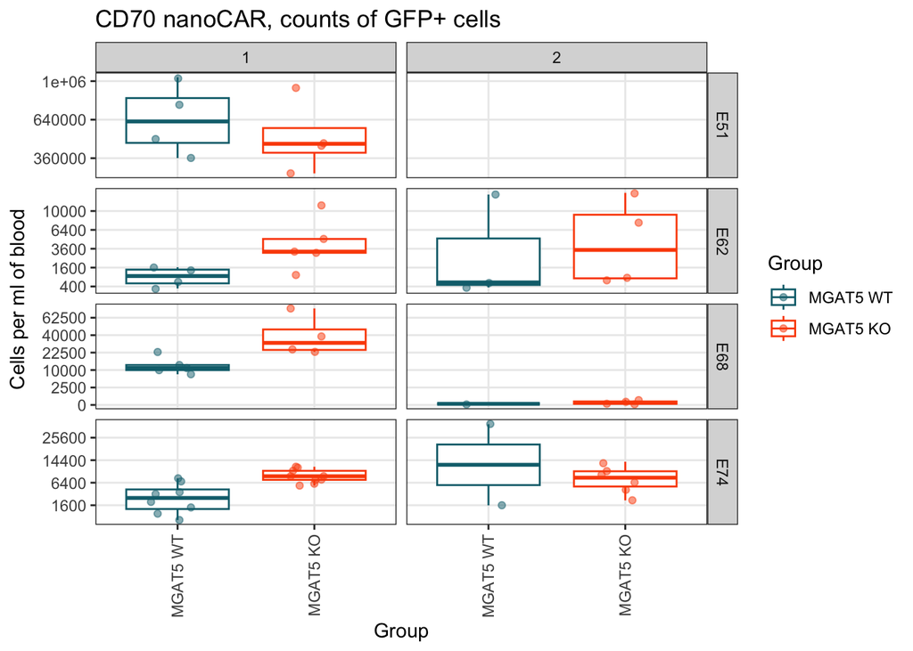

```r
CD70_box <- data %>%
  filter(Target == 'CD70') %>%
  filter(Experiment %in% c('E51', 'E62', 'E68', 'E74')) %>%
  filter(TimePoint %in% c(1,2)) %>%
  ggplot(aes(x = Group, y = CellCount, color = Group)) +
  geom_boxplot(outlier.shape = NA) +
  geom_jitter(width = 0.2, alpha = 0.5) +
  facet_grid2(Experiment~TimePoint, scales = 'free_y') +
  scale_y_continuous(trans = 'sqrt') +
  scale_x_discrete(guide = guide_axis(angle = 90)) +
  theme_bw() +
  scale_colour_manual(values = c(
    #rgb(44,20,83, maxColorValue = 255),
    rgb(14,111,124, maxColorValue = 255),
    rgb(251,79,6, maxColorValue = 255))) +
  labs(y = 'Cells per ml of blood') +
  ggtitle('CD70 nanoCAR, counts of GFP+ cells') +
  scale_y_facet(Experiment == 'E51',
                breaks = c(0,200,400,600,800,1000),
                labels = (c(0,200,400,600,800,1000))^2) +
  scale_y_facet(Experiment == 'E62',
                breaks = c(0,20,40,60,80,100),
                labels = (c(0,20,40,60,80,100))^2) +
  scale_y_facet(Experiment == 'E68',
                breaks = c(0,50,100,150,200,250),
                labels = (c(0,50,100,150,200,250))^2) +
  scale_y_facet(Experiment == 'E74',
                breaks = c(0,40,80,120,160,200),
                labels = (c(0,40,80,120,160,200))^2) +
  theme(panel.grid.minor = element_blank())

ggsave(here("output/CellCountsBoxplot_CD70_Raji_PerExp_byTimePoint.pdf"), CD70_box,
       device = "pdf", height = 8, width = 10, dpi=600)

CD70_box
```

Number of mice:

```r
data %>%
  filter(Target %in% c('NTC', 'CD70')) %>%
  filter(Experiment %in% c('E51', 'E62', 'E68', 'E74')) %>%
  group_by(TimePoint, Group, Experiment) %>%
  count()
```

```
## # A tibble: 21 × 4
## # Groups:   TimePoint, Group, Experiment [21]
##    TimePoint Group    Experiment     n
##    <fct>     <fct>    <fct>      <int>
##  1 1         NTC      E51            3
##  2 1         NTC      E62            4
##  3 1         NTC      E68            3
##  4 1         NTC      E74            5
##  5 1         MGAT5 WT E51            4
##  6 1         MGAT5 WT E62            4
##  7 1         MGAT5 WT E68            5
##  8 1         MGAT5 WT E74            8
##  9 1         MGAT5 KO E51            4
## 10 1         MGAT5 KO E62            5
## 11 1         MGAT5 KO E68            4
## 12 1         MGAT5 KO E74            9
## 13 2         MGAT5 WT E62            3
## 14 2         MGAT5 WT E68            1
## 15 2         MGAT5 WT E74            2
## 16 2         MGAT5 KO E62            4
## 17 2         MGAT5 KO E68            4
## 18 2         MGAT5 KO E74            6
## 19 3         MGAT5 WT E74            1
## 20 3         MGAT5 KO E74            4
## 21 4         MGAT5 KO E74            1
```

## Plot for CD19

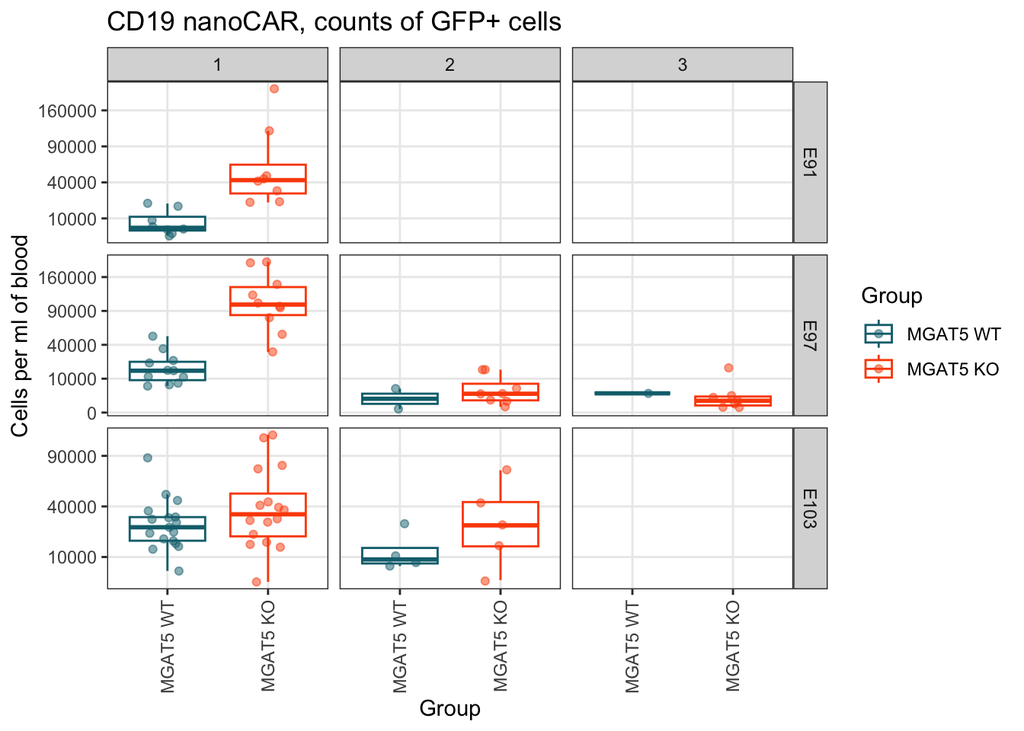

```r
CD19_box <- data %>%
  filter(Target == 'CD19') %>%
  filter(TimePoint != 1.5) %>%
  ggplot(aes(x = Group, y = CellCount, color = Group)) +
  geom_boxplot(outlier.shape = NA) +
  geom_jitter(width = 0.2, alpha = 0.5) +
  facet_grid2(Experiment~TimePoint, scales = 'free_y') +
  scale_y_continuous(trans = 'sqrt') +
  scale_x_discrete(guide = guide_axis(angle = 90)) +
  theme_bw() +
  scale_colour_manual(values = c(
    #rgb(44,20,83, maxColorValue = 255),
    rgb(14,111,124, maxColorValue = 255),
    rgb(251,79,6, maxColorValue = 255))) +
  labs(y = 'Cells per ml of blood') +
  ggtitle('CD19 nanoCAR, counts of GFP+ cells') +
  scale_y_facet(Experiment == 'E91',
                breaks = c(0,100,200,300,400),
                labels = (c(0,100,200,300,400))^2) +
  scale_y_facet(Experiment == 'E97',
                breaks = c(0,100,200,300,400),
                labels = (c(0,100,200,300,400))^2) +
  scale_y_facet(Experiment == 'E103',
                breaks = c(0,100,200,300,400),
                labels = (c(0,100,200,300,400))^2) +
  theme(panel.grid.minor = element_blank())

ggsave(here("output/CellCountsBoxplot_CD19_Raji_PerExp_byTimePoint.pdf"), CD19_box,
       device = "pdf", height = 8, width = 10, dpi=600)

CD19_box
```

Number of mice:

```r
data %>%
  filter(Target %in% c('NTC', 'CD19')) %>%
  filter(Experiment %in% c('E91', 'E97', 'E103')) %>%
  group_by(TimePoint, Group, Experiment) %>%
  count()
```

```
## # A tibble: 17 × 4
## # Groups:   TimePoint, Group, Experiment [17]
##    TimePoint Group    Experiment     n
##    <fct>     <fct>    <fct>      <int>
##  1 1         NTC      E91            8
##  2 1         NTC      E97            6
##  3 1         NTC      E103           9
##  4 1         MGAT5 WT E91            8
##  5 1         MGAT5 WT E97           11
##  6 1         MGAT5 WT E103          17
##  7 1         MGAT5 KO E91            8
##  8 1         MGAT5 KO E97           10
##  9 1         MGAT5 KO E103          16
## 10 1.5       MGAT5 WT E103          11
## 11 1.5       MGAT5 KO E103          10
## 12 2         MGAT5 WT E97            2
## 13 2         MGAT5 WT E103           4
## 14 2         MGAT5 KO E97            8
## 15 2         MGAT5 KO E103           5
## 16 3         MGAT5 WT E97            1
## 17 3         MGAT5 KO E97            7
```

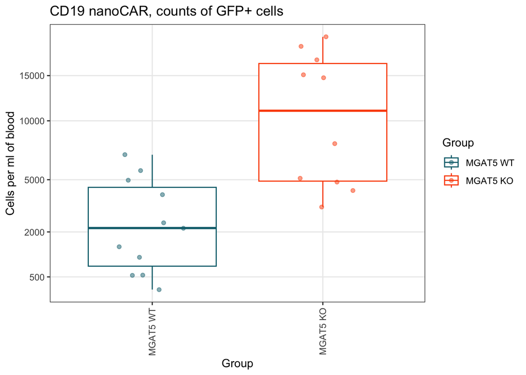

```r
CD19_box_tp1.5 <- data %>%
  filter(Target == 'CD19') %>%
  filter(TimePoint == 1.5) %>%
  ggplot(aes(x = Group, y = CellCount, color = Group)) +
  geom_boxplot(outlier.shape = NA) +
  geom_jitter(width = 0.2, alpha = 0.5) +
  scale_x_discrete(guide = guide_axis(angle = 90)) +
  theme_bw() +
  scale_colour_manual(values = c(
    #rgb(44,20,83, maxColorValue = 255),
    rgb(14,111,124, maxColorValue = 255),
    rgb(251,79,6, maxColorValue = 255))) +
  labs(y = 'Cells per ml of blood') +
  ggtitle('CD19 nanoCAR, counts of GFP+ cells') +
  scale_y_continuous(trans = 'sqrt', breaks = c(0, 500, 2000, 5000, 10000, 15000)) +
  theme(panel.grid.minor = element_blank())

ggsave(here("output/CellCountsBoxplot_CD19_Raji_PerExp_TimePoint_1_5.pdf"), CD19_box_tp1.5,
       device = "pdf", height = 8, width = 10, dpi=600)

CD19_box_tp1.5
```

# Models

We will now continue with modeling the counts: - We model CD19 and CD70 data separately, each time using the same NTC. - We model each time-point separately. - We only make a contrast for MGAT5 WT vs MGAT5 KO.

We will model these data with a quasipoisson model, which is suited for overdispersed count data and uses a log-link.

## CD70

plot data for which we are going to test

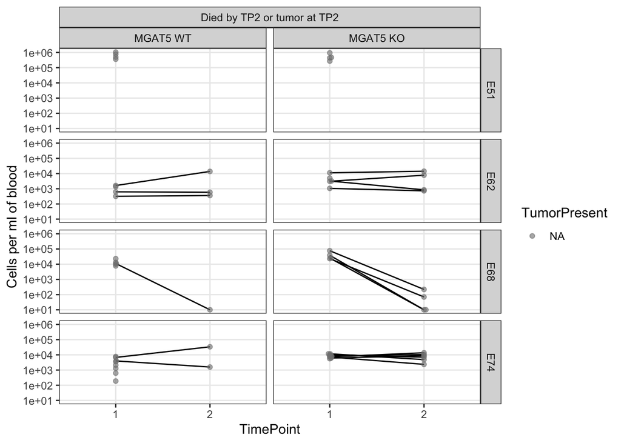

```r
data %>%
  filter(Target %in% c('CD70')) %>%
  filter(TimePoint %in% c(1,2)) %>%
  ggplot(aes(x = TimePoint, y = CellCount)) +
  geom_line(aes(group = ID)) +
  geom_beeswarm(alpha = 0.6, aes(color = TumorPresent)) +
  ggh4x::facet_nested(Experiment ~ Tumorfree_tp2+Group) +
  scale_y_continuous(transform = 'pseudo_log',
                     breaks = c(0,1,10,100,1000,10000,100000,1000000)) +
  theme_bw() +
  labs(y = 'Cells per ml of blood') +
  theme(panel.grid.minor = element_blank())
```

```r
modeldata <- data %>%
  filter(Target %in% c('CD70')) %>%
  filter(TimePoint %in% c(1,2)) %>%
  group_by(Target, Experiment, TimePoint) %>%
  nest() %>%
  mutate(data = purrr::map(data, ~.x %>% droplevels()))
```

```r
modeldata <- modeldata %>%
  rowwise() %>%
  filter(length(unique(data$Treatment))==2) %>%
  mutate(model = list(glm(CellCount ~ Group, data = data, family = quasipoisson)),
         logFC = model$coefficients['GroupMGAT5 KO'] %>% as.numeric,
         pval = summary(model)$coefficients['GroupMGAT5 KO','Pr(>|t|)'],
         data = list(data %>% mutate(
           pred = predict(model, type = 'response'))))

modeldata %>%
  select(Experiment, Target, TimePoint, pval) %>%
  arrange(Target, Experiment, TimePoint) %>%
  ungroup() %>%
  mutate(pval = ifelse(pval<0.001, '<0.001', round(pval, 3))) %>%
  write_xlsx(here('output/CellCountTests_CD70_Raji_M5vsWT.xlsx'))
```

Model predictions

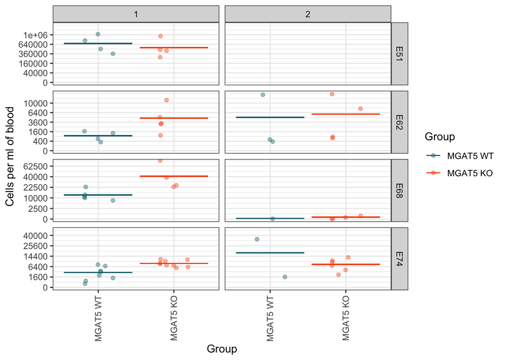

```r
modeldata$ID <- 1:nrow(modeldata)

data_aug <- bind_rows(modeldata$data, .id = "ID") %>%
  mutate(ID = as.numeric(ID))

data_aug <- left_join(data_aug, modeldata %>% select(ID, Experiment, Target, TimePoint))

BloodPlots <- data_aug %>%
  ggplot(aes(x = Group, y = CellCount, color = Group)) +
  geom_errorbar(aes(y = pred, color = Group, ymin = pred, ymax = pred)) +
  geom_jitter(alpha = 0.4, width = 0.2) +
  facet_grid2(Experiment~TimePoint, scales = 'free_y') +
  scale_x_discrete(guide = guide_axis(angle = 90)) +
  scale_y_continuous(trans = 'sqrt') +
  theme_bw() +
  scale_colour_manual(values = c(
    #rgb(44,20,83, maxColorValue = 255),
    rgb(14,111,124, maxColorValue = 255),
    rgb(251,79,6, maxColorValue = 255))) +
  scale_y_facet(Experiment == 'E51',
                limits = c(0, 1200),
                breaks = c(0,200,400,600,800,1000),
                labels = (c(0,200,400,600,800,1000))^2) +
  scale_y_facet(Experiment == 'E62',
                limits = c(0, 120),
                breaks = c(0,20,40,60,80,100),
                labels = (c(0,20,40,60,80,100))^2) +
  scale_y_facet(Experiment == 'E68',
                limits = c(0, 270),
                breaks = c(0,50,100,150,200,250),
                labels = (c(0,50,100,150,200,250))^2) +
  scale_y_facet(Experiment == 'E74',
                limits = c(0, 220),
                breaks = c(0,40,80,120,160,200),
                labels = (c(0,40,80,120,160,200))^2) +
  labs(y = 'Cells per ml of blood')

BloodPlots
```

```r
ggsave(here("output/CellCountMedianPlots_CD70_Raji_PerExp_byTimePoint.pdf"), BloodPlots,
       device = "pdf", height = 8, width = 8, dpi=600)
```

## CD19

```r
modeldata <- data %>%
  filter(Target %in% c('CD19')) %>%
  group_by(Target, Experiment, TimePoint) %>%
  nest() %>%
  mutate(data = purrr::map(data, ~.x %>% droplevels()))
```

```r
modeldata <- modeldata %>%
  rowwise() %>%
  filter(length(unique(data$Treatment))==2) %>%
  mutate(model = list(glm(CellCount ~ Group, data = data, family = quasipoisson)),
         logFC = model$coefficients['GroupMGAT5 KO'] %>% as.numeric,
         pval = summary(model)$coefficients['GroupMGAT5 KO','Pr(>|t|)'],
         data = list(data %>% mutate(
           pred = predict(model, type = 'response'))))

modeldata %>%
  select(Experiment, Target, pval) %>%
  arrange(Target, Experiment, TimePoint) %>%
  ungroup() %>%
  mutate(pval = ifelse(pval<0.001, '<0.001', round(pval, 3))) %>%
  write_xlsx(here('output/CellCountTests_CD19_Raji_M5vsWT.xlsx'))
```

Model predictions

```r
modeldata$ID <- 1:nrow(modeldata)

data_aug <- bind_rows(modeldata$data, .id = "ID") %>%
  mutate(ID = as.numeric(ID))

data_aug <- left_join(data_aug, modeldata %>% select(ID, Experiment, Target, TimePoint))

BloodPlots <- data_aug %>%
  filter(TimePoint != 1.5) %>%
  ggplot(aes(x = Group, y = CellCount, color = Group)) +
  geom_errorbar(aes(y = pred, color = Group, ymin = pred, ymax = pred)) +
  geom_jitter(alpha = 0.4, width = 0.2) +
  facet_grid2(Experiment~TimePoint, scales = 'free_y') +
  scale_x_discrete(guide = guide_axis(angle = 90)) +
  scale_y_continuous(trans = 'sqrt') +
  theme_bw() +
  scale_colour_manual(values = c(
    #rgb(44,20,83, maxColorValue = 255),
    rgb(14,111,124, maxColorValue = 255),
    rgb(251,79,6, maxColorValue = 255))) +
  scale_y_facet(Experiment == 'E91',
                limits = c(0, 500),
                breaks = c(0,100,200,300,400),
                labels = (c(0,100,200,300,400))^2) +
  scale_y_facet(Experiment == 'E97',
                limits = c(0, 500),
                breaks = c(0,100,200,300,400),
                labels = (c(0,100,200,300,400))^2) +
  scale_y_facet(Experiment == 'E103',
                breaks = c(0,100,200,300,400),
                labels = (c(0,100,200,300,400))^2)
  labs(y = 'Cells per ml of blood')
```

```
## <ggplot2::labels> List of 1
##  $ y: chr "Cells per ml of blood"
```

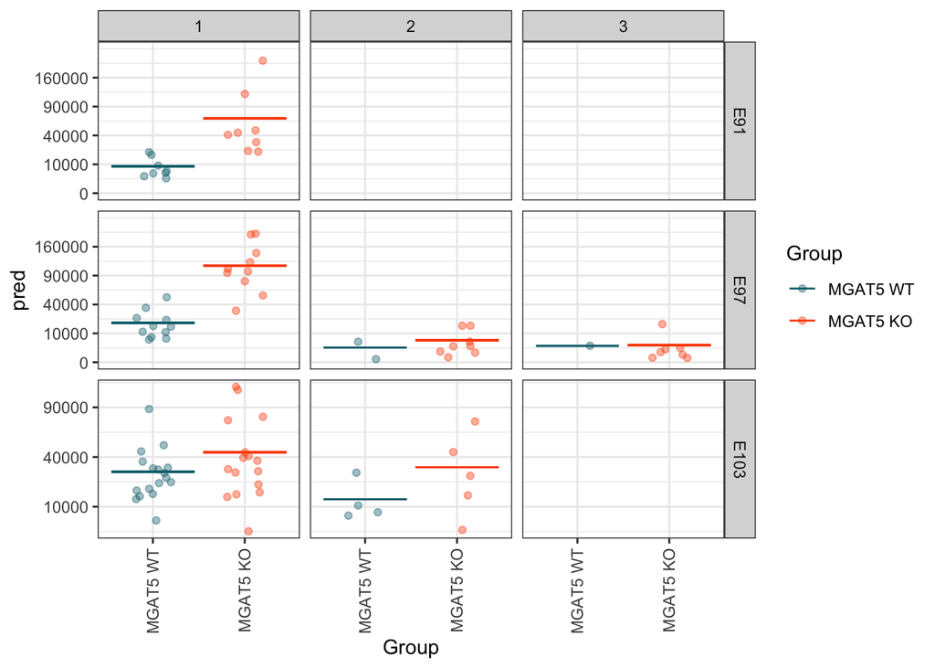

```r
BloodPlots
```

```r
ggsave(here("output/CellCountMedianPlots_CD19_Raji_PerExp_byTimePoint.pdf"), BloodPlots,
       device = "pdf", height = 5, width = 10, dpi=600)
```

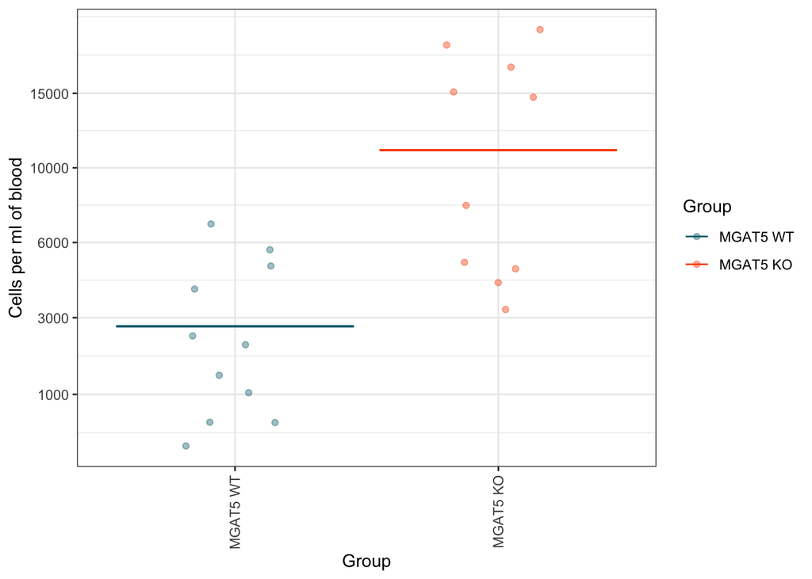

```r
BloodPlots_tp1_5 <- data_aug %>%
  filter(TimePoint == 1.5) %>%
  ggplot(aes(x = Group, y = CellCount, color = Group)) +
  geom_errorbar(aes(y = pred, color = Group, ymin = pred, ymax = pred)) +
  geom_jitter(alpha = 0.4, width = 0.2) +
  scale_x_discrete(guide = guide_axis(angle = 90)) +
  scale_y_continuous(trans = 'sqrt',
                     breaks = c(1000, 3000, 6000, 10000, 15000)) +
  theme_bw() +
  scale_colour_manual(values = c(
    #rgb(44,20,83, maxColorValue = 255),
    rgb(14,111,124, maxColorValue = 255),
    rgb(251,79,6, maxColorValue = 255))) +
  labs(y = 'Cells per ml of blood')

BloodPlots_tp1_5
```

```r
ggsave(here("output/CellCountMedianPlots_CD19_Raji_PerExp_TimePoint_1_5.pdf"), BloodPlots_tp1_5,
       device = "pdf", height = 6, width = 6, dpi=600)
```

# Materials and Methods

We ran quasipoisson models in R [ref], using the glm function with Cell Counts per ml of blood as the outcome variable and Group (MGAT5KO vs WT) as predictor. The presented p-values were then extracted from the model.

```r
citation()
```

```
##
##   R Core Team (2025). _R: A Language and Environment for Statistical
##   Computing_. R Foundation for Statistical Computing, Vienna, Austria.
##   <https://www.R-project.org/>.
##
## A BibTeX entry for LaTeX users is
##
##   @Manual{,
##     title = {R: A Language and Environment for Statistical Computing},
##     author = {{R Core Team}},
##     organization = {R Foundation for Statistical Computing},
##     address = {Vienna, Austria},
##     year = {2025},
##     url = {https://www.R-project.org/},
##   }
##
## We have invested a lot of time and effort in creating R, please cite it
## when using it for data analysis. See also 'citation("pkgname")' for
## citing R packages.
```